# Data Analysis for Age and Demografics

# Instructions

## Required R packages

- `tidyverse` (or `ggplot2`, `dplyr`, `purrr`, `tibble`)
- `brms`
- `devtools` (for installing `faintr`)
- `rstan`
- `faintr` (install with `devtools`)

Load the required packages and set a seed for the random number generator.

```r
library(tidyverse)

library(rstan)
# set cores to use to the total number of cores (minimally 4)
options(mc.cores = max(parallel::detectCores(), 4))
# save a compiled version of the Stan model file
rstan_options(auto_write = TRUE)

library(brms)

library(gmodels)

# install faintr with devtools::install_github('michael-franke/bayes_mixed_regression_tutorial/faintr', build_vignettes = TRUE))
library(faintr)

set.seed(123)
```

## Step 1. Read the data and take a glimpse of it.

```r
data_raw <- read_csv("results_71_givemegestalt_group3_group3.csv")
glimpse(data_raw)
```

```
## Observations: 12,078
## Variables: 24
## $ submission_id  <dbl> 566, 566, 566, 566, 566, 566, 566, 566, 566, 56...
## $ QUD            <lgl> NA, NA, NA, NA, NA, NA, NA, NA, NA, NA, NA, NA,...
## $ RT             <dbl> 57807, 13595, 14410, 4927, 4493, 2380, 2907, 66...
## $ age            <dbl> 20, 20, 20, 20, 20, 20, 20, 20, 20, 20, 20, 20,...
## $ comments       <chr> NA, NA, NA, NA, NA, NA, NA, NA, NA, NA, NA, NA,...
## $ endTime        <dbl> 1.562946e+12, 1.562946e+12, 1.562946e+12, 1.562...
## $ experiment_id  <dbl> 71, 71, 71, 71, 71, 71, 71, 71, 71, 71, 71, 71,...
## $ fileID         <dbl> NA, NA, 26, 3, 11, 4, 22, 33, 17, 60, 23, 59, 5...
## $ gender         <chr> "female", "female", "female", "female", "female...
## $ is_expert      <chr> "No", "No", "No", "No", "No", "No", "No", "No",...
## $ min_chars      <dbl> 0, NA, NA, NA, NA, NA, NA, NA, NA, NA, NA, NA, ...
## $ option1        <chr> NA, "Yes", NA, NA, NA, NA, NA, NA, NA, NA, NA, ...
## $ option2        <chr> NA, "No", NA, NA, NA, NA, NA, NA, NA, NA, NA, N...
## $ optionLeft     <chr> NA, NA, "not at all", "not at all", "not at all...
## $ optionRight    <chr> NA, NA, "very much", "very much", "very much", ...
## $ picture        <chr> "images/snellen/snellen.png", NA, "images/stimu...
## $ question       <chr> "Which row is the last one where you can recogn...
## $ response       <chr> "9", "No", "6", "5", "3", "3", "1", "5", "4", "...
## $ snellen_result <dbl> 9, 9, 9, 9, 9, 9, 9, 9, 9, 9, 9, 9, 9, 9, 9, 9,...
## $ startDate      <chr> "Fri Jul 12 2019 17:34:17 GMT+0200 (Mitteleurop...
## $ startTime      <dbl> 1.562946e+12, 1.562946e+12, 1.562946e+12, 1.562...
## $ timeSpent      <dbl> 11.90795, 11.90795, 11.90795, 11.90795, 11.9079...
## $ trial_name     <chr> "test_snellen", "b0_expert", "b1_exp", "b1_exp"...
## $ trial_number   <dbl> 1, 1, 1, 2, 3, 4, 5, 6, 7, 8, 9, 10, 11, 12, 13...
```

Step 2. Select only the columns of interest and filter trials that are not interesting for the calculations. Change data type of the responses to double and submission_id to factor. Delete invalid participants. —

```r
data_selection <- select(data_raw, submission_id, snellen_result, is_expert, age, gender, trial_name, trial_number, fileID, response, RT, timeSpent, comments)
data_filtered <- filter(data_selection, trial_name != "test_snellen", trial_name != "b0_expert")
data_mut <- mutate(data_filtered, response = as.double(response), submission_id = factor(submission_id))

show(data_selection)
```

```
## # A tibble: 12,078 x 12
##    submission_id snellen_result is_expert   age gender trial_name
##            <dbl>          <dbl> <chr>     <dbl> <chr>  <chr>
##  1           566              9 No           20 female test_snel~
##  2           566              9 No           20 female b0_expert
##  3           566              9 No           20 female b1_exp
##  4           566              9 No           20 female b1_exp
##  5           566              9 No           20 female b1_exp
##  6           566              9 No           20 female b1_exp
##  7           566              9 No           20 female b1_exp
##  8           566              9 No           20 female b1_exp
##  9           566              9 No           20 female b1_exp
## 10           566              9 No           20 female b1_exp
## # ... with 12,068 more rows, and 6 more variables: trial_number <dbl>,
## #   fileID <dbl>, response <chr>, RT <dbl>, timeSpent <dbl>,
## #   comments <chr>
```

```r
show(data_filtered)
```

```
## # A tibble: 11,880 x 12
##    submission_id snellen_result is_expert   age gender trial_name
##            <dbl>          <dbl> <chr>     <dbl> <chr>  <chr>
##  1           566              9 No           20 female b1_exp
##  2           566              9 No           20 female b1_exp
##  3           566              9 No           20 female b1_exp
##  4           566              9 No           20 female b1_exp
##  5           566              9 No           20 female b1_exp
##  6           566              9 No           20 female b1_exp
##  7           566              9 No           20 female b1_exp
##  8           566              9 No           20 female b1_exp
##  9           566              9 No           20 female b1_exp
## 10           566              9 No           20 female b1_exp
## # ... with 11,870 more rows, and 6 more variables: trial_number <dbl>,
## #   fileID <dbl>, response <chr>, RT <dbl>, timeSpent <dbl>,
## #   comments <chr>
```

```r
show(data_mut)
```

```
## # A tibble: 11,880 x 12
##    submission_id snellen_result is_expert   age gender trial_name
##    <fct>                  <dbl> <chr>     <dbl> <chr>  <chr>
##  1 566                        9 No           20 female b1_exp
##  2 566                        9 No           20 female b1_exp
##  3 566                        9 No           20 female b1_exp
##  4 566                        9 No           20 female b1_exp
##  5 566                        9 No           20 female b1_exp
##  6 566                        9 No           20 female b1_exp
##  7 566                        9 No           20 female b1_exp
##  8 566                        9 No           20 female b1_exp
##  9 566                        9 No           20 female b1_exp
## 10 566                        9 No           20 female b1_exp
## # ... with 11,870 more rows, and 6 more variables: trial_number <dbl>,
## #   fileID <dbl>, response <dbl>, RT <dbl>, timeSpent <dbl>,
## #   comments <chr>
```

```r
# 3 participants only rated "1" in both blocks, one participant only rated "7", one gave a invalid input for the Snellen test, we exclude them:
data_clean <- filter(data_mut, submission_id != 607, submission_id != 736, submission_id != 475, submission_id != 480, submission_id != 726)
show(data_clean)
```

```
## # A tibble: 11,280 x 12
##    submission_id snellen_result is_expert   age gender trial_name
##    <fct>                  <dbl> <chr>     <dbl> <chr>  <chr>
##  1 566                        9 No           20 female b1_exp
##  2 566                        9 No           20 female b1_exp
##  3 566                        9 No           20 female b1_exp
##  4 566                        9 No           20 female b1_exp
##  5 566                        9 No           20 female b1_exp
##  6 566                        9 No           20 female b1_exp
##  7 566                        9 No           20 female b1_exp
##  8 566                        9 No           20 female b1_exp
##  9 566                        9 No           20 female b1_exp
## 10 566                        9 No           20 female b1_exp
## # ... with 11,270 more rows, and 6 more variables: trial_number <dbl>,
## #   fileID <dbl>, response <dbl>, RT <dbl>, timeSpent <dbl>,
## #   comments <chr>
```

## Step.3 Demografics

```r
data_rawdemografics <- select(data_clean, submission_id, age, gender, is_expert, snellen_result, comments)
data_demografics <- dplyr::distinct(group_by(data_rawdemografics, submission_id))
show(data_demografics[order(data_demografics$submission_id),])
```

```
## # A tibble: 94 x 6
## # Groups:   submission_id [94]
##    submission_id   age gender is_expert snellen_result comments
##    <fct>         <dbl> <chr>  <chr>              <dbl> <chr>
##  1 458              51 male   Yes                    9 <NA>
##  2 459              20 female Yes                    9 <NA>
##  3 460              18 female No                     9 <NA>
##  4 461              63 male   No                    10 <NA>
##  5 462              29 female No                     9 <NA>
##  6 463              56 female No                     7 <NA>
##  7 464              21 female No                    10 <NA>
##  8 465              21 female No                     9 <NA>
##  9 466              19 female No                     8 <NA>
## 10 467              23 male   No                    10 <NA>
## # ... with 84 more rows
```

Total number of participents:

```r
length(unique(data_clean$submission_id))
```

```
## [1] 94
```

Detecting the gender data provided and their count:

```r
data_gender_male <- filter(data_clean,gender == "male")
data_gender_female <- filter(data_clean,gender == "female")
data_gender_diverse <- filter(data_clean,gender == "divers")
length(data_gender_male$gender)/120
```

```
## [1] 33
```

```r
length(data_gender_female$gender)/120
```

```
## [1] 57
```

```r
length(data_gender_diverse$gender)/120
```

```
## [1] 2
```

```r
sum(is.na(data_clean$gender))/120 # counting how many NA are there.
```

```
## [1] 2
```

There are total 33 male participents, 57 female and 2 of them identify their gender as diverse and 2 of them did not submitted the data about gender.

Data set according to age:

```r
data_age_below_20 <- filter(data_clean,age <= 19)
data_age_20_40<-filter(data_clean,age>=20&age<=40)
data_age_ab_40 <- filter(data_clean,age > 40)
#divide by 120 beacuse there are 120 entries per person
length(data_age_below_20$age)/120
```

```
## [1] 14
```

```r
length(data_age_20_40$age)/120
```

```
## [1] 69
```

```r
length(data_age_ab_40$age)/120
```

```
## [1] 10
```

```r
sum(is.na(data_clean$age))/120
```

```
## [1] 1
```

From all participants there are in total 14 participants, who are below age of 20, 69 are in range of 20 - 40 and 10 are in range of 41 to 63. 1 participants did not give data for age.

## Step 4. Split data according to trial (b1: Liking, b2: Detactability).

```r
#Data with all participants
data_b1 <- filter(data_clean, trial_name == "b1_exp")
data_b2 <- filter(data_clean, trial_name == "b2_exp")
```

## Step 5. Age and Liking/ Age and Detectability

```r
data_b1_age <- group_by(data_b1, age) %>% summarise(mean_Like = mean(response))
data_b2_age <- group_by(data_b2, age) %>% summarise(mean_Detect = mean(response))

final_data_age0 <- merge(x = data_b2_age, y = data_b1_age, by = "age")
final_data_age <- na.omit(final_data_age0) # delete NA.
show(final_data_age)
```

```
##    age mean_Detect mean_Like
## 1   13    4.583333  4.133333
## 2   14    4.333333  3.622222
## 3   16    2.516667  3.733333
## 4   17    3.800000  4.116667
## 5   18    4.983333  4.100000
## 6   19    4.521429  3.230952
## 7   20    3.581818  3.439394
## 8   21    3.863889  3.172222
## 9   22    4.178571  3.680952
## 10  23    3.583333  3.464286
## 11  24    3.683333  3.142593
## 12  25    3.927778  3.894444
## 13  26    4.154167  3.945833
## 14  27    3.611111  3.405556
## 15  28    4.750000  4.105556
## 16  29    5.050000  4.725000
## 17  30    3.266667  2.375000
## 18  32    4.566667  2.666667
## 19  33    3.583333  2.216667
## 20  37    3.050000  3.633333
## 21  42    4.450000  5.133333
## 22  50    3.983333  4.116667
## 23  51    4.833333  4.316667
## 24  53    3.916667  4.716667
## 25  56    3.775000  3.866667
## 26  58    5.066667  4.200000
## 27  59    2.950000  3.483333
## 28  60    3.833333  4.566667
## 29  63    4.683333  4.216667
```

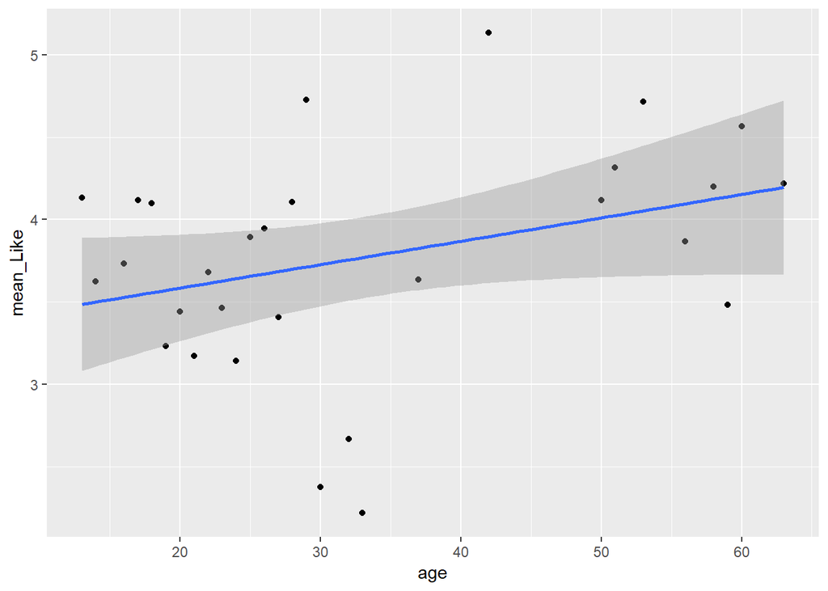

```r
ggplot(final_data_age, aes(x = age, y = mean_Like)) + geom_point() + geom_smooth(method = "lm")
```

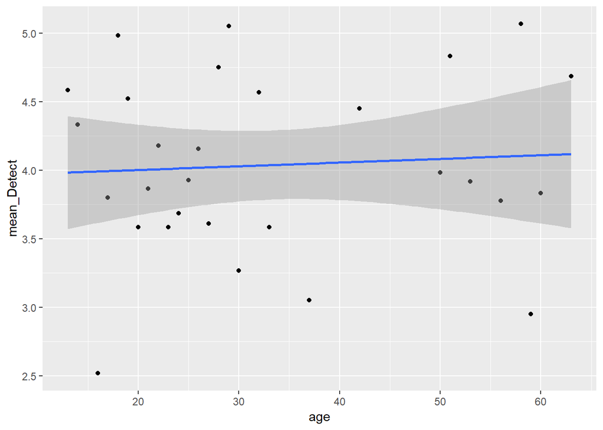

```r
ggplot(final_data_age, aes(x = age, y = mean_Detect)) + geom_point() + geom_smooth(method = "lm")
```

```r
cor(final_data_age$age, final_data_age$mean_Like)
```

```
## [1] 0.335604
```

```r
cor(final_data_age$age, final_data_age$mean_Detect)
```

```
## [1] 0.06599213
```

```r
summary(lm(final_data_age$mean_Like ~ final_data_age$age))
```

```
##
## Call:
## lm(formula = final_data_age$mean_Like ~ final_data_age$age)
##
## Residuals:
##      Min       1Q   Median       3Q      Max
## -1.55205 -0.27799  0.07637  0.40782  1.23684
##
## Coefficients:
##                    Estimate Std. Error t value Pr(>|t|)
## (Intercept)        3.300236   0.282257  11.692 4.49e-12 ***
## final_data_age$age 0.014197   0.007669   1.851   0.0751 .
## ---
## Signif. codes:  0 '***' 0.001 '**' 0.01 '*' 0.05 '.' 0.1 ' ' 1
##
## Residual standard error: 0.6466 on 27 degrees of freedom
## Multiple R-squared:  0.1126, Adjusted R-squared:  0.07976
## F-statistic: 3.427 on 1 and 27 DF,  p-value: 0.07511
```